# Load the data for enrichment analysis

**Citation:** if you use MAGeCKFlute in published research, please cite: Binbin Wang, Mei Wang, Wubing Zhang. “Integrative analysis of pooled CRISPR genetic screens using MAGeCKFlute.” Nature Protocols (2019), doi: [10.1038/s41596-018-0113-7](https://www.nature.com/articles/s41596-018-0113-7).t

## Load the data for enrichment analysis

```r
library(MAGeCKFlute)
data(rra.gene_summary)
df = ReadRRA(rra.gene_summary)
genelist= df$Score
names(genelist) = df$id
```

## Enrichment analysis methods

MAGeCKFlute incorporates three enrichment methods, including Over-Representation Test (ORT), Gene Set Enrichment Analysis (GSEA), and Hypergeometric test (HGT). Here, ORT and GSEA are borrowed from R package clusterProfiler.

### Hypergeometric test

```r
# Alternative functions EnrichAnalyzer and enrich.HGT.
hgtRes1 = EnrichAnalyzer(genelist[genelist< -1], method = "HGT")
head(hgtRes1@result)
```

```
##                                ID
## REACTOME:72163     REACTOME:72163
## REACTOME:6791226 REACTOME:6791226
## KEGG:03040             KEGG:03040
## REACTOME:72165     REACTOME:72165
## REACTOME:9010553 REACTOME:9010553
## REACTOME:2467813 REACTOME:2467813
##                                                                    Description
## REACTOME:72163                                   mRNA Splicing - Major Pathway
## REACTOME:6791226 Major pathway of rRNA processing in the nucleolus and cytosol
## KEGG:03040                                                         Spliceosome
## REACTOME:72165                                   mRNA Splicing - Minor Pathway
## REACTOME:9010553                   Regulation of expression of SLITs and ROBOs
## REACTOME:2467813                               Separation of Sister Chromatids
##                         NES       pvalue     p.adjust GeneRatio BgRatio
## REACTOME:72163   -16.134860 4.265984e-22 1.821575e-19    49/183 183/183
## REACTOME:6791226 -15.585134 1.656555e-18 3.536744e-16    45/186 186/186
## KEGG:03040       -13.075227 1.221878e-13 1.739140e-11    34/149 149/149
## REACTOME:72165    -9.292907 1.131860e-12 1.208261e-10     19/52   52/52
## REACTOME:9010553 -13.519650 1.828458e-12 1.561503e-10    35/171 171/177
## REACTOME:2467813 -13.696330 1.056148e-11 7.516256e-10    36/190 190/190
##                                                                                                                                                                                                                                                                                         geneID
## REACTOME:72163   10772/7536/23020/55339/23517/1479/25804/5094/5433/3192/9343/…
## REACTOME:6791226                      81887/6122/9045/5394/55127/23481/6193/92856/23517/83732/6202…
## KEGG:03040                                                                                        10772/23020/25804/3192/9343/57819/56949/6632/1665/3312/55119/10262/9775/23451/6426/4686/1659/56259/22938/8175/27339/6428/27316/9984/10286/10523/6625/7307/51340/10992/84950/6626/27258/10713
## REACTOME:72165                                                                                                                                                                          23020/79622/5433/9343/57819/6632/10081/10262/23451/6426/4686/5430/8233/11066/5434/5435/10992/5438/5440
## REACTOME:9010553                                                                                              6122/9045/5684/6193/6923/5692/6202/5686/6188/6224/5695/5691/5689/9978/6187/5708/6207/6194/6222/5688/9775/5714/5718/5702/10213/6205/6209/4686/6234/8453/6135/23521/6168/6232/6147
## REACTOME:2467813                                                                              11243/5684/9212/5692/9184/25936/5686/8243/5695/5691/1778/5689/5708/5518/5885/5688/5714/5718/5702/10213/147841/29945/5347/81930/29882/8697/10403/10376/54820/701/4085/6232/54908/23279/51433/1060
##                                                                                                                                                                                                                                                                                                          …
## REACTOME:72163   SRSF10/SF1/SNRNP200/WDR33/SKIV2L2/CSTF3/LSM4/PCBP2/POLR2D/HN…
## REACTOME:6791226                                    LAS1L/RPL3/RPL14/EXOSC10/HEATR1/PES1/RPS5/IMP4/SKIV2L2/RIOK1…
## KEGG:03040                                                                                                     SRSF10/SNRNP200/LSM4/HNRNPU/EFTUD2/LSM2/XAB2/SNRPD/DHX15/HSP…
## REACTOME:72165                                                                                                                                                                                        SNRNP200/SNRNP25/POLR2D/EFTUD2/LSM2/SNRPD/PDCD7/SF3B4/SF3B1/SRSF1/NCBP1/POLR2A/ZRSR2/SNRNP35/POLR2E…
## REACTOME:9010553                                                                                                     RPL3/RPL14/PSMA3/RPS5/TCEB2/PSMB4/RPS8/PSMA5/RPS3/RPS20/PSMB…
## REACTOME:2467813                                                                                    PMF1/PSMA3/AURKB/PSMB4/BUB3/NSL1/PSMA5/SMC1A/PSMB7/PSMB3/DYN…
##                  Count
## REACTOME:72163      49
## REACTOME:6791226    45
## KEGG:03040          34
## REACTOME:72165      19
## REACTOME:9010553    35
## REACTOME:2467813    36
```

```r
hgtRes2 = enrich.HGT(genelist[genelist< -1])
head(hgtRes2@result)
```

```
##                                ID
## REACTOME:72163     REACTOME:72163
## REACTOME:6791226 REACTOME:6791226
## KEGG:03040             KEGG:03040
## REACTOME:72165     REACTOME:72165
## REACTOME:9010553 REACTOME:9010553
## REACTOME:2467813 REACTOME:2467813
##                                                                    Description
## REACTOME:72163                                   mRNA Splicing - Major Pathway
## REACTOME:6791226 Major pathway of rRNA processing in the nucleolus and cytosol
## KEGG:03040                                                         Spliceosome
## REACTOME:72165                                   mRNA Splicing - Minor Pathway
## REACTOME:9010553                   Regulation of expression of SLITs and ROBOs
## REACTOME:2467813                               Separation of Sister Chromatids
##                         NES       pvalue     p.adjust GeneRatio BgRatio
## REACTOME:72163   -16.134860 4.265984e-22 1.821575e-19    49/183 183/183
## REACTOME:6791226 -15.585134 1.656555e-18 3.536744e-16    45/186 186/186
## KEGG:03040       -13.075227 1.221878e-13 1.739140e-11    34/149 149/149
## REACTOME:72165    -9.292907 1.131860e-12 1.208261e-10     19/52   52/52
## REACTOME:9010553 -13.519650 1.828458e-12 1.561503e-10    35/171 171/177
## REACTOME:2467813 -13.696330 1.056148e-11 7.516256e-10    36/190 190/190
##                                                                                                                                                                                                                                                                                         geneID
## REACTOME:72163   10772/7536/23020/55339/23517/1479/25804/5094/5433/3192/9343/…
## REACTOME:6791226                      81887/6122/9045/5394/55127/23481/6193/92856/23517/83732/6202…
## KEGG:03040                                                                                        10772/23020/25804/3192/9343/57819/56949/6632/1665/3312/55119/10262/9775/23451/6426/4686/1659/56259/22938/8175/27339/6428/27316/9984/10286/10523/6625/7307/51340/10992/84950/6626/27258/10713
## REACTOME:72165                                                                                                                                                                          23020/79622/5433/9343/57819/6632/10081/10262/23451/6426/4686/5430/8233/11066/5434/5435/10992/5438/5440
## REACTOME:9010553                                                                                              6122/9045/5684/6193/6923/5692/6202/5686/6188/6224/5695/5691/5689/9978/6187/5708/6207/6194/6222/5688/9775/5714/5718/5702/10213/6205/6209/4686/6234/8453/6135/23521/6168/6232/6147
## REACTOME:2467813                                                                              11243/5684/9212/5692/9184/25936/5686/8243/5695/5691/1778/5689/5708/5518/5885/5688/5714/5718/5702/10213/147841/29945/5347/81930/29882/8697/10403/10376/54820/701/4085/6232/54908/23279/51433/1060
##                                                                                                                                                                                                                                                                                                          …
## REACTOME:72163   SRSF10/SF1/SNRNP200/WDR33/SKIV2L2/CSTF3/LSM4/PCBP2/POLR2D/HN…
## REACTOME:6791226                                    LAS1L/RPL3/RPL14/EXOSC10/HEATR1/PES1/RPS5/IMP4/SKIV2L2/RIOK1…
## KEGG:03040                                                                                                     SRSF10/SNRNP200/LSM4/HNRNPU/EFTUD2/LSM2/XAB2/SNRPD/DHX15/HSP…
## REACTOME:72165                                                                                                                                                                                        SNRNP200/SNRNP25/POLR2D/EFTUD2/LSM2/SNRPD/PDCD7/SF3B4/SF3B1/SRSF1/NCBP1/POLR2A/ZRSR2/SNRNP35/POLR2E…
## REACTOME:9010553                                                                                                     RPL3/RPL14/PSMA3/RPS5/TCEB2/PSMB4/RPS8/PSMA5/RPS3/RPS20/PSMB…
## REACTOME:2467813                                                                                    PMF1/PSMA3/AURKB/PSMB4/BUB3/NSL1/PSMA5/SMC1A/PSMB7/PSMB3/DYN…
##                  Count
## REACTOME:72163      49
## REACTOME:6791226    45
## KEGG:03040          34
## REACTOME:72165      19
## REACTOME:9010553    35
## REACTOME:2467813    36
```

### Over-representation test

```r
# Alternative functions EnrichAnalyzer and enrich.ORT.
ortRes1 = EnrichAnalyzer(genelist[genelist< -1], method = "ORT")
head(ortRes1@result)
```

```
##                                ID
## REACTOME:72163     REACTOME:72163
## REACTOME:6791226 REACTOME:6791226
## KEGG:03040             KEGG:03040
## REACTOME:9010553 REACTOME:9010553
## REACTOME:2467813 REACTOME:2467813
## REACTOME:72165     REACTOME:72165
##                                                                    Description
## REACTOME:72163                                   mRNA Splicing - Major Pathway
## REACTOME:6791226 Major pathway of rRNA processing in the nucleolus and cytosol
## KEGG:03040                                                         Spliceosome
## REACTOME:9010553                   Regulation of expression of SLITs and ROBOs
## REACTOME:2467813                               Separation of Sister Chromatids
## REACTOME:72165                                   mRNA Splicing - Minor Pathway
##                         NES       pvalue     p.adjust GeneRatio   BgRatio
## REACTOME:72163   -16.134860 1.673403e-24 1.698504e-21    49/504 183/10846
## REACTOME:6791226 -15.585134 1.253945e-20 6.363772e-18    45/504 186/10846
## KEGG:03040       -13.075227 4.952327e-15 1.675537e-12    34/504 149/10846
## REACTOME:9010553 -13.519650 6.479656e-14 1.644213e-11    35/504 171/10846
## REACTOME:2467813 -13.696330 3.326864e-13 6.753535e-11    36/504 190/10846
## REACTOME:72165    -9.292907 6.217695e-13 1.051827e-10    19/504  52/10846
##                                                                                                                                                                                                                                                                                         geneID
## REACTOME:72163   10772/7536/23020/55339/23517/1479/25804/5094/5433/3192/9343/…
## REACTOME:6791226                      81887/6122/9045/5394/55127/23481/6193/92856/23517/83732/6202…
## KEGG:03040                                                                                        10772/23020/25804/3192/9343/57819/56949/6632/1665/3312/55119/10262/9775/23451/6426/4686/1659/56259/22938/8175/27339/6428/27316/9984/10286/10523/6625/7307/51340/10992/84950/6626/27258/10713
## REACTOME:9010553                                                                                              6122/9045/5684/6193/6923/5692/6202/5686/6188/6224/5695/5691/5689/9978/6187/5708/6207/6194/6222/5688/9775/5714/5718/5702/10213/6205/6209/4686/6234/8453/6135/23521/6168/6232/6147
## REACTOME:2467813                                                                              11243/5684/9212/5692/9184/25936/5686/8243/5695/5691/1778/5689/5708/5518/5885/5688/5714/5718/5702/10213/147841/29945/5347/81930/29882/8697/10403/10376/54820/701/4085/6232/54908/23279/51433/1060
## REACTOME:72165                                                                                                                                                                          23020/79622/5433/9343/57819/6632/10081/10262/23451/6426/4686/5430/8233/11066/5434/5435/10992/5438/5440
##                                                                                                                                                                                                                                                                                                          …
## REACTOME:72163   SRSF10/SF1/SNRNP200/WDR33/MTREX/CSTF3/LSM4/PCBP2/POLR2D/HNRN…
## REACTOME:6791226                                       LAS1L/RPL3/RPL14/EXOSC10/HEATR1/PES1/RPS5/IMP4/MTREX/RIOK1/R…
## KEGG:03040                                                                                                   SRSF10/SNRNP200/LSM4/HNRNPU/EFTUD2/LSM2/XAB2/SNRPD1/DHX15/HS…
## REACTOME:9010553                                                                                                     RPL3/RPL14/PSMA3/RPS5/ELOB/PSMB4/RPS8/PSMA5/RPS3/RPS20/PSMB7…
## REACTOME:2467813                                                                                    PMF1/PSMA3/AURKB/PSMB4/BUB3/NSL1/PSMA5/SMC1A/PSMB7/PSMB3/DYN…
## REACTOME:72165                                                                                                                                                                                      SNRNP200/SNRNP25/POLR2D/EFTUD2/LSM2/SNRPD1/PDCD7/SF3B4/SF3B1/SRSF1/NCBP1/POLR2A/ZRSR2/SNRNP35/POLR2E/…
##                  Count
## REACTOME:72163      49
## REACTOME:6791226    45
## KEGG:03040          34
## REACTOME:9010553    35
## REACTOME:2467813    36
## REACTOME:72165      19
```

```r
ortRes2 = enrich.ORT(genelist[genelist< -1])
head(ortRes2@result)
```

```
##                                ID
## REACTOME:72163     REACTOME:72163
## REACTOME:6791226 REACTOME:6791226
## KEGG:03040             KEGG:03040
## REACTOME:9010553 REACTOME:9010553
## REACTOME:2467813 REACTOME:2467813
## REACTOME:72165     REACTOME:72165
##                                                                    Description
## REACTOME:72163                                   mRNA Splicing - Major Pathway
## REACTOME:6791226 Major pathway of rRNA processing in the nucleolus and cytosol
## KEGG:03040                                                         Spliceosome
## REACTOME:9010553                   Regulation of expression of SLITs and ROBOs
## REACTOME:2467813                               Separation of Sister Chromatids
## REACTOME:72165                                   mRNA Splicing - Minor Pathway
##                         NES       pvalue     p.adjust GeneRatio   BgRatio
## REACTOME:72163   -16.134860 1.673403e-24 1.698504e-21    49/504 183/10846
## REACTOME:6791226 -15.585134 1.253945e-20 6.363772e-18    45/504 186/10846
## KEGG:03040       -13.075227 4.952327e-15 1.675537e-12    34/504 149/10846
## REACTOME:9010553 -13.519650 6.479656e-14 1.644213e-11    35/504 171/10846
## REACTOME:2467813 -13.696330 3.326864e-13 6.753535e-11    36/504 190/10846
## REACTOME:72165    -9.292907 6.217695e-13 1.051827e-10    19/504  52/10846
##                                                                                                                                                                                                                                                                                         geneID
## REACTOME:72163   10772/7536/23020/55339/23517/1479/25804/5094/5433/3192/9343/…
## REACTOME:6791226                      81887/6122/9045/5394/55127/23481/6193/92856/23517/83732/6202…
## KEGG:03040                                                                                        10772/23020/25804/3192/9343/57819/56949/6632/1665/3312/55119/10262/9775/23451/6426/4686/1659/56259/22938/8175/27339/6428/27316/9984/10286/10523/6625/7307/51340/10992/84950/6626/27258/10713
## REACTOME:9010553                                                                                              6122/9045/5684/6193/6923/5692/6202/5686/6188/6224/5695/5691/5689/9978/6187/5708/6207/6194/6222/5688/9775/5714/5718/5702/10213/6205/6209/4686/6234/8453/6135/23521/6168/6232/6147
## REACTOME:2467813                                                                              11243/5684/9212/5692/9184/25936/5686/8243/5695/5691/1778/5689/5708/5518/5885/5688/5714/5718/5702/10213/147841/29945/5347/81930/29882/8697/10403/10376/54820/701/4085/6232/54908/23279/51433/1060
## REACTOME:72165                                                                                                                                                                          23020/79622/5433/9343/57819/6632/10081/10262/23451/6426/4686/5430/8233/11066/5434/5435/10992/5438/5440
##                                                                                                                                                                                                                                                                                                          …
## REACTOME:72163   SRSF10/SF1/SNRNP200/WDR33/MTREX/CSTF3/LSM4/PCBP2/POLR2D/HNRN…
## REACTOME:6791226                                       LAS1L/RPL3/RPL14/EXOSC10/HEATR1/PES1/RPS5/IMP4/MTREX/RIOK1/R…
## KEGG:03040                                                                                                   SRSF10/SNRNP200/LSM4/HNRNPU/EFTUD2/LSM2/XAB2/SNRPD1/DHX15/HS…
## REACTOME:9010553                                                                                                     RPL3/RPL14/PSMA3/RPS5/ELOB/PSMB4/RPS8/PSMA5/RPS3/RPS20/PSMB7…
## REACTOME:2467813                                                                                    PMF1/PSMA3/AURKB/PSMB4/BUB3/NSL1/PSMA5/SMC1A/PSMB7/PSMB3/DYN…
## REACTOME:72165                                                                                                                                                                                      SNRNP200/SNRNP25/POLR2D/EFTUD2/LSM2/SNRPD1/PDCD7/SF3B4/SF3B1/SRSF1/NCBP1/POLR2A/ZRSR2/SNRNP35/POLR2E/…
##                  Count
## REACTOME:72163      49
## REACTOME:6791226    45
## KEGG:03040          34
## REACTOME:9010553    35
## REACTOME:2467813    36
## REACTOME:72165      19
```

### Gene set enrichment analysis

```r
# Alternative functions EnrichAnalyzer and enrich.GSE.
gseRes1 = EnrichAnalyzer(genelist, method = "GSEA")
head(gseRes1@result)
```

```
##                                ID
## REACTOME:2467813 REACTOME:2467813
## KEGG:05016             KEGG:05016
## KEGG:05010             KEGG:05010
## REACTOME:72163     REACTOME:72163
## REACTOME:6791226 REACTOME:6791226
## REACTOME:9010553 REACTOME:9010553
##                                                                    Description
## REACTOME:2467813                               Separation of Sister Chromatids
## KEGG:05016                                                  Huntington disease
## KEGG:05010                                                   Alzheimer disease
## REACTOME:72163                                   mRNA Splicing - Major Pathway
## REACTOME:6791226 Major pathway of rRNA processing in the nucleolus and cytosol
## REACTOME:9010553                   Regulation of expression of SLITs and ROBOs
##                        NES       pvalue    p.adjust
## REACTOME:2467813 -2.390912 0.0005089059 0.008328724
## KEGG:05016       -1.858095 0.0005091650 0.008328724
## KEGG:05010       -1.541730 0.0005107252 0.008328724
## REACTOME:72163   -2.426972 0.0005109862 0.008328724
## REACTOME:6791226 -2.456700 0.0005130836 0.008328724
## REACTOME:9010553 -2.291676 0.0005133470 0.008328724
##                                                                                                                                                                                                                                                                                                          …
## REACTOME:2467813                                                             5719/5682/23244/57551/23198/9735/11130/54821/9793/9126/55746…
## KEGG:05016                                                                                                                                                                                                                                                                 6874/1349/7350/4728/4713/6392/…
## KEGG:05010                                                                                                                                                                                                                                                341947/2081/805/6391/163688/23621/100532726/558…
## REACTOME:72163                   25949/8683/8189/53981/22827/55749/9416/57794/81608/79869/110…
## REACTOME:6791226 705/3921/28987/55759/6158/54913/6157/200916/55131/10607/2289…
## REACTOME:9010553                                                                                                                                                                           5719/5682/6157/200916/23198/2107/5709/7979/10197/6235/6176/5…
##                                                                                                                                                                                                                                                                                                          …
## REACTOME:2467813                                        PSMD13/PSMA1/PDS5A/TAOK1/PSME4/KNTC1/ZWINT/ERCC6L/CKAP5/SMC3…
## KEGG:05016                                                                                                                                                                                                                              TAF4/COX7B/UCP1/NDUFS8/NDUFB7/SDHD/NDUFS7/NDUFB1/NDUFA10/ATP…
## KEGG:05010                                                                                                                                                                                                          COX8C/ERN1/CALM2/SDHC/CALML6/BACE1/NDUFC2-KCTD14/PSENEN/UQCRC1/SDHB/COX6B2/NDUFB5/NDU…
## REACTOME:72163   SYF2/SRSF9/SYMPK/CPSF2/PUF60/CCAR1/DDX23/SUGP1/FIP1L1/CPSF7/…
## REACTOME:6791226           BYSL/RPSA/NOB1/WDR12/RPL28/RPP25/RPL27A/RPL22L1/RBM28/TBL3/D…
## REACTOME:9010553                                                                                                                                                              PSMD13/PSMA1/RPL27A/RPL22L1/PSME4/ETF1/PSMD3/SEM1/PSME3/RPS2…
##                  Count
## REACTOME:2467813    81
## KEGG:05016          49
## KEGG:05010          50
## REACTOME:72163      87
## REACTOME:6791226    89
## REACTOME:9010553    64
```

```r
gseRes2 = enrich.GSE(genelist)
head(gseRes2@result)
```

```
##                                ID
## KEGG:05016             KEGG:05016
## REACTOME:2467813 REACTOME:2467813
## REACTOME:72163     REACTOME:72163
## REACTOME:9010553 REACTOME:9010553
## REACTOME:6791226 REACTOME:6791226
## KEGG:03013             KEGG:03013
##                                                                    Description
## KEGG:05016                                                  Huntington disease
## REACTOME:2467813                               Separation of Sister Chromatids
## REACTOME:72163                                   mRNA Splicing - Major Pathway
## REACTOME:9010553                   Regulation of expression of SLITs and ROBOs
## REACTOME:6791226 Major pathway of rRNA processing in the nucleolus and cytosol
## KEGG:03013                                                       RNA transport
##                        NES       pvalue   p.adjust
## KEGG:05016       -1.880645 0.0005070994 0.00752476
## REACTOME:2467813 -2.420829 0.0005076142 0.00752476
## REACTOME:72163   -2.457840 0.0005115090 0.00752476
## REACTOME:9010553 -2.323917 0.0005115090 0.00752476
## REACTOME:6791226 -2.490836 0.0005117707 0.00752476
## KEGG:03013       -2.244383 0.0005178664 0.00752476
##                                                                                                                                                                                                                                                                                                          …
## KEGG:05016                                                                                                                                                                                                                                                                 6874/1349/7350/4728/4713/6392/…
## REACTOME:2467813                                                             5719/5682/23244/57551/23198/9735/11130/54821/9793/9126/55746…
## REACTOME:72163                   25949/8683/8189/53981/22827/55749/9416/57794/81608/79869/110…
## REACTOME:9010553                                                                                                                                                                           5719/5682/6157/200916/23198/2107/5709/7979/10197/6235/6176/5…
## REACTOME:6791226 705/3921/28987/55759/6158/54913/6157/200916/55131/10607/2289…
## KEGG:03013                                                                                                                                                                                                                             8666/3646/54913/96764/9972/55746/7175/11097/79228/6396/1915/…
##                                                                                                                                                                                                                                                                                                          …
## KEGG:05016                                                                                                                                                                                                                              TAF4/COX7B/UCP1/NDUFS8/NDUFB7/SDHD/NDUFS7/NDUFB1/NDUFA10/ATP…
## REACTOME:2467813                                        PSMD13/PSMA1/PDS5A/TAOK1/PSME4/KNTC1/ZWINT/ERCC6L/CKAP5/SMC3…
## REACTOME:72163   SYF2/SRSF9/SYMPK/CPSF2/PUF60/CCAR1/DDX23/SUGP1/FIP1L1/CPSF7/…
## REACTOME:9010553                                                                                                                                                              PSMD13/PSMA1/RPL27A/RPL22L1/PSME4/ETF1/PSMD3/SEM1/PSME3/RPS2…
## REACTOME:6791226           BYSL/RPSA/NOB1/WDR12/RPL28/RPP25/RPL27A/RPL22L1/RBM28/TBL3/D…
## KEGG:03013                                                                                                                                                                                                                              EIF3G/EIF3E/RPP25/TGS1/NUP153/NUP133/TPR/NUP42/THOC6/SEC13/E…
##                  Count
## KEGG:05016          49
## REACTOME:2467813    81
## REACTOME:72163      87
## REACTOME:9010553    64
## REACTOME:6791226    89
## KEGG:03013          52
```

## Visualize enrichment results.

### Barplot

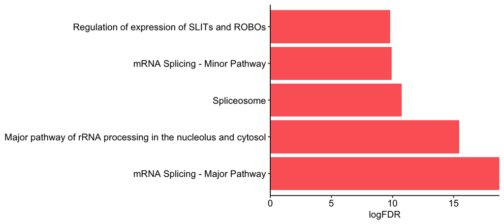

```r
require(ggplot2)
df = hgtRes1@result
df$logFDR = -log10(df$p.adjust)
p = BarView(df[1:5,], "Description", 'logFDR')
p = p + labs(x = NULL) + coord_flip()
p
```

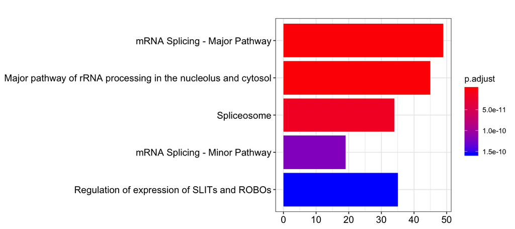

```r
# Or use function barplot from enrichplot package
barplot(hgtRes1, showCategory = 5)
```

### Dot plot

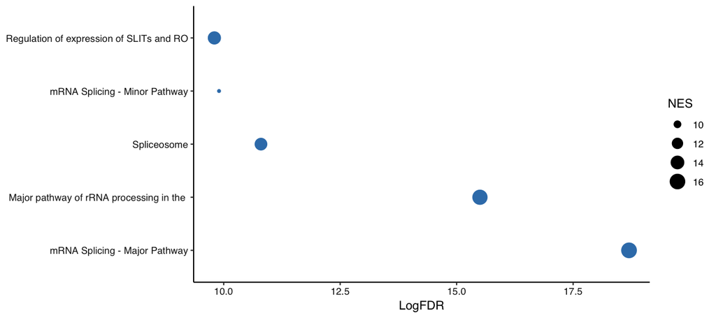

```r
EnrichedView(hgtRes1, bottom = 5)
```

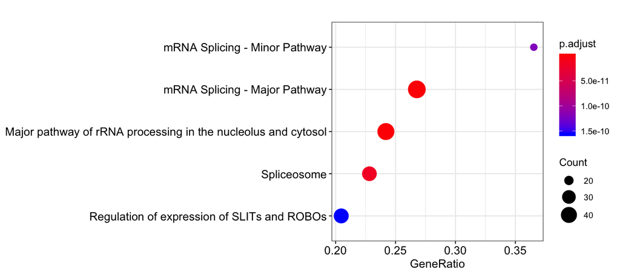

```r
dotplot(hgtRes1, showCategory = 5)
```

### Visualization functions from [enrichplot](https://yulab-smu.github.io/clusterProfiler-book/chapter12.html).

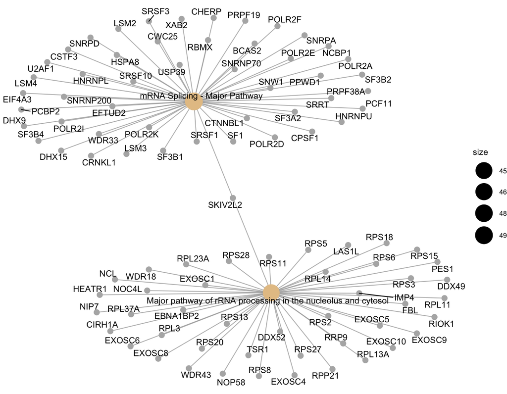

```r
hgtRes1@result$geneID = hgtRes1@result$geneName
#cnetplot
cnetplot(hgtRes1, 2)
```

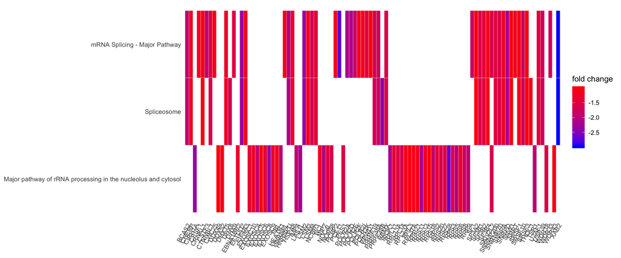

```r
heatplot(hgtRes1, showCategory = 3, foldChange=genelist)
```

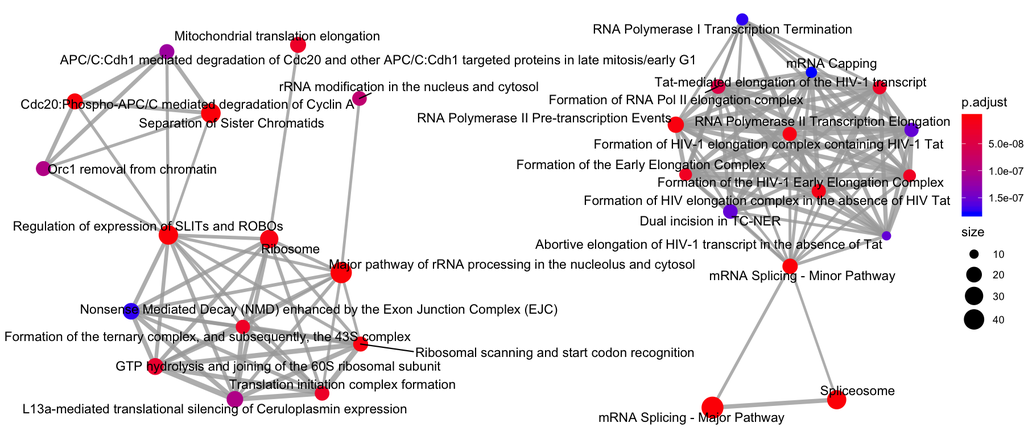

```r
emapplot(hgtRes1, layout="kk")
```

### Visulization for GSEA enriched categories

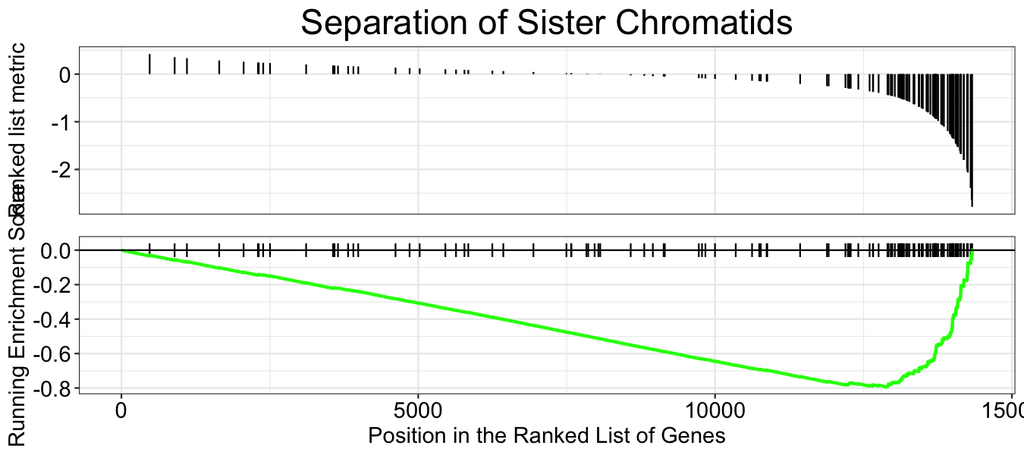

```r
#gseaplot
gseaplot(gseRes1, geneSetID = 1, title = gseRes1$Description[1])
```

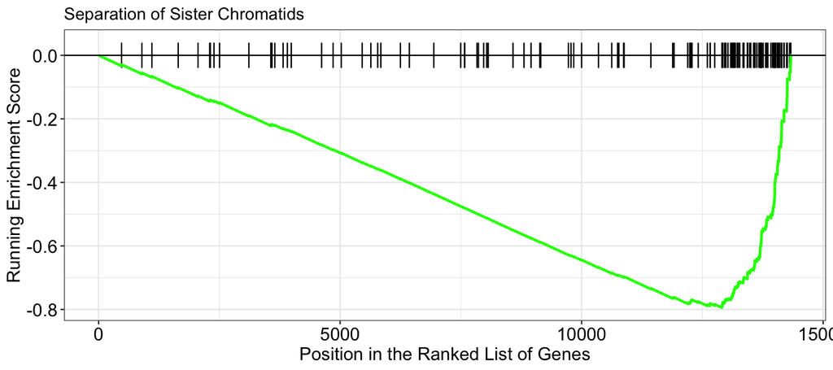

```r
gseaplot(gseRes1, geneSetID = 1, by = "runningScore", title = gseRes1$Description[1])
```

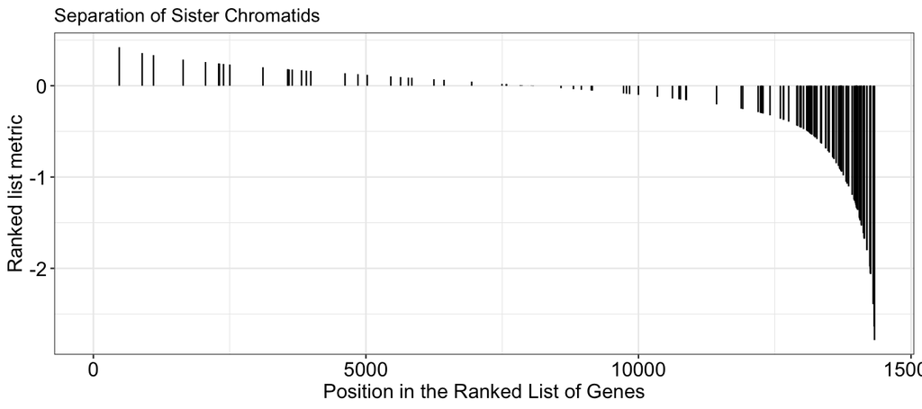

```r
gseaplot(gseRes1, geneSetID = 1, by = "preranked", title = gseRes1$Description[1])
```

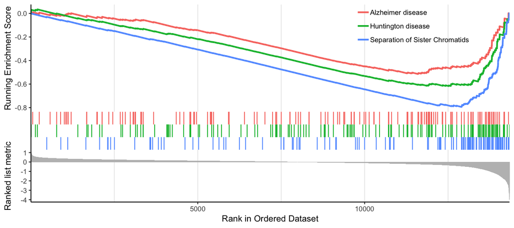

```r
#or
gseaplot2(gseRes1, geneSetID = 1:3)
```

## Type of gene sets for enrichment analysis

For enrichment analysis, MAGeCKFlute signifies the public available gene sets, including Pathways (PID, KEGG, REACTOME, BIOCARTA, C2CP), GO terms (GOBP, GOCC, GOMF), Complexes (CORUM, CPX) and molecular signature from MsigDB (c1, c2, c3, c4, c6, c7, HALLMARK).

### Functional enrichment analysis on GO terms and pathways

Analysis of high-throughput data increasingly relies on pathway annotation and functional information derived from Gene Ontology, which is also useful in the analysis of CRISPR screens.

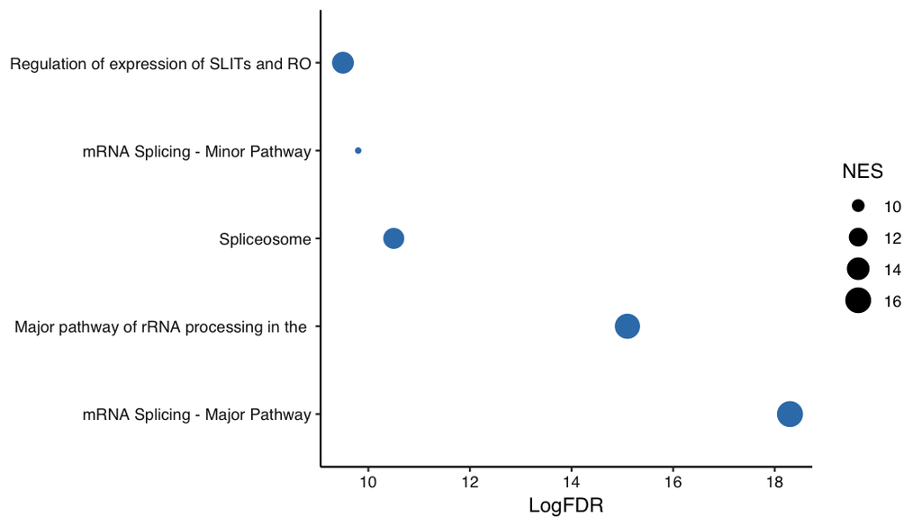

```r
## KEGG and REACTOME pathways
enrich = EnrichAnalyzer(geneList = genelist[genelist< -1], type = "KEGG+REACTOME")
EnrichedView(enrich, bottom = 5)
```

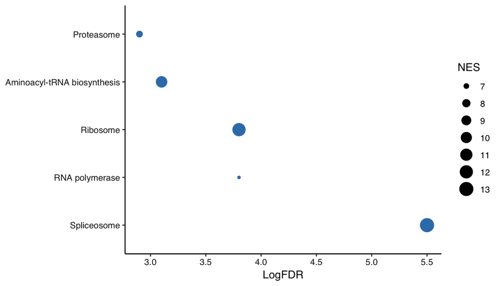

```r
## Only KEGG pathways
enrich = EnrichAnalyzer(geneList = genelist[genelist< -1], type = "KEGG")
EnrichedView(enrich, bottom = 5)
```

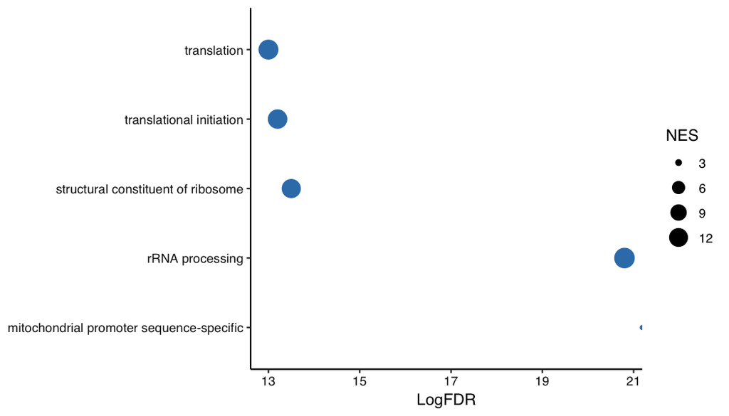

```r
## Gene ontology
enrichGo = EnrichAnalyzer(genelist[genelist< -1], type = "GOBP+GOMF")
EnrichedView(enrichGo, bottom = 5)
```

### Protein complex analysis

Functional annotations from the pathways and GO are powerful in the context of network dynamics. However, the approach has limitations in particular for the analysis of CRISPR screenings, in which elements within a protein complex rather than complete pathways might have a strong selection. So we incorporate protein complex resource from CORUM and CPX database, which enable identification of essential protein complexes from the CRISPR screens.

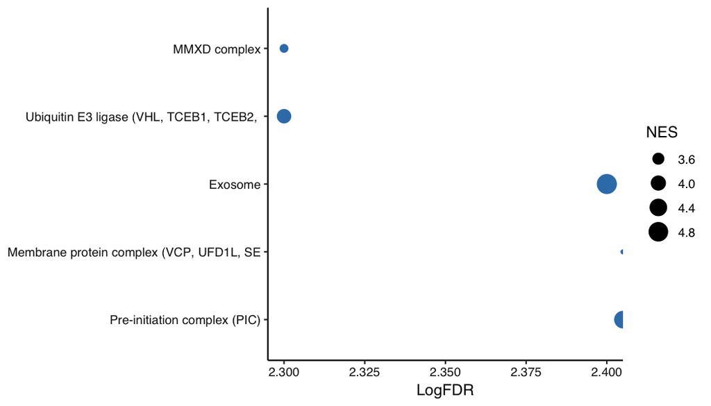

```r
enrichPro = EnrichAnalyzer(genelist[genelist< -1], type = "CORUM+CPX")
EnrichedView(enrichPro, bottom = 5)
```

### Enrichment analysis on the combination of the gene sets

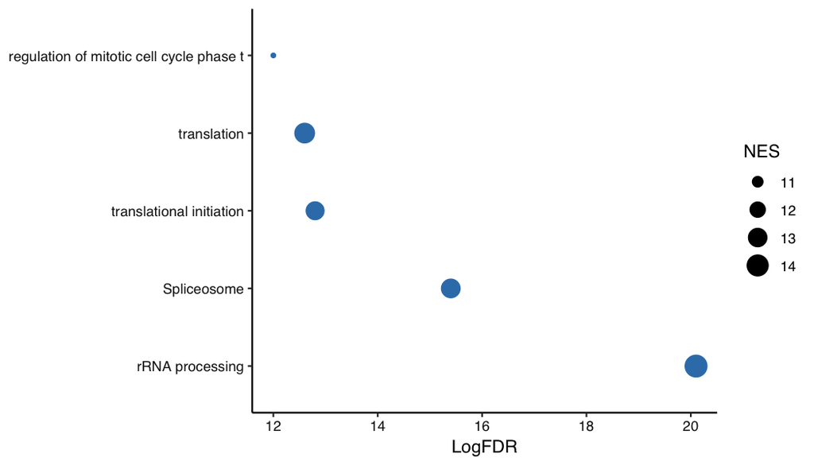

```r
enrichComb = EnrichAnalyzer(genelist[genelist< -1], type = "GOBP+KEGG")
EnrichedView(enrichComb, bottom = 5)
```

## Limit the size of gene sets for testing

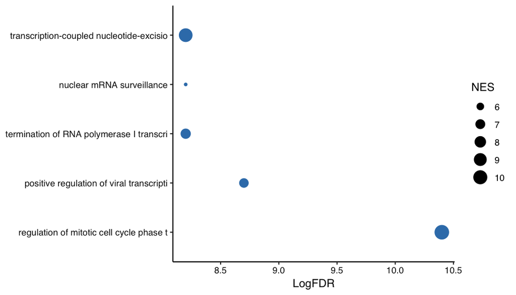

```r
enrich = EnrichAnalyzer(genelist[genelist< -1], type = "GOBP", limit = c(1, 80))
EnrichedView(enrich, bottom = 5)
```

## Remove redundant results using `EnrichedFilter`.

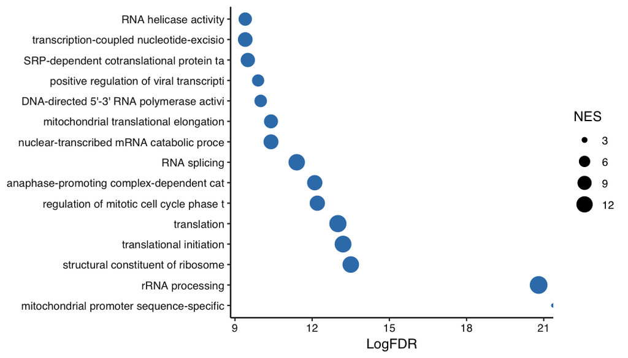

```r
enrich1 = EnrichAnalyzer(genelist[genelist< -1], type = "GOMF+GOBP")
enrich2 = EnrichAnalyzer(genelist[genelist< -1], type = "GOMF+GOBP", filter = TRUE)
enrich3 = EnrichedFilter(enrich1)
EnrichedView(enrich1, bottom = 15)
```

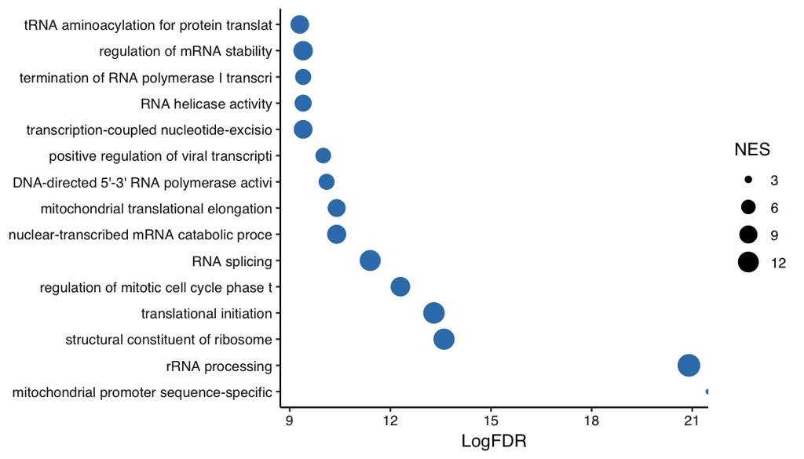

```r
EnrichedView(enrich2, bottom = 15)
```

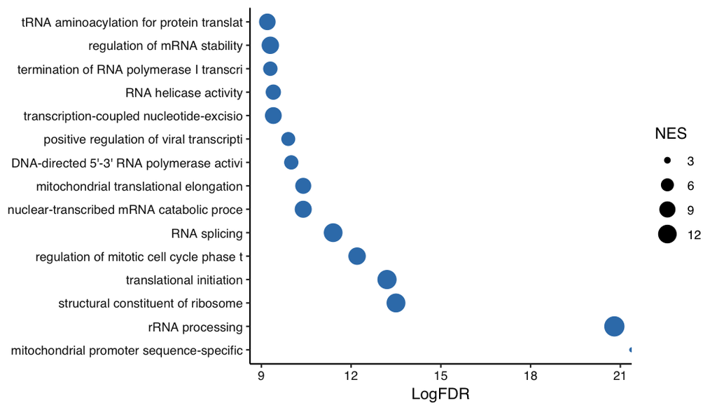

```r
EnrichedView(enrich3, bottom = 15)
```